# Pregunta_MonteCarlo

2025-05-13

## PREGUNTA 1:

Propongan una pregunta de investigación original, que involucre la comparación de una frecuencia de un evento o característica en dos grupos independientes. Fijando una semilla propia, seleccionen una muestra aleatoria de hogares (100 < n < 150) y respondan la pregunta propuesta utilizando el método Monte Carlo.

¿Existe una diferencia significativa en la proporción de personas que han completado la educación media entre quienes actualmente tienen entre 18 y 30 años (personas después de la reforma educacional de 2003) y quienes tienen entre 31 y 44 años (personas antes de la reforma), en la Región Metropolitana según los datos CASEN 2017?

Empezamos cargando los datos y las librerías necesarias:

```r
library(dplyr)
casen <- read.csv("EP08 Datos CASEN 2017.csv", stringsAsFactors = TRUE)
```

Ahora seleccionamos una muestra aleatoria de la Región Metropolitana:

```r
set.seed(0) # Para reproducibilidad

# Seleccionar muestra aleatoria en Región Metropolitana de personas entre 18 y 44 años
n_muestra <- 120
Datos_filtrados_aleatorios <- casen %>%
  filter(region == "Región Metropolitana de Santiago") %>%
  filter(edad >= 18 & edad <= 44) %>%  # rango 18 a 44 años
  filter(!is.na(e6a)) %>%
  sample_n(size = n_muestra)
```

Transformamos la educación en binario, donde 1 representa educación alta y 0 educación baja y agregamos columnas a cada persona con el si han completado o no al menos la educación medía:

```r
# Crear una función para transformar los niveles educativos en binarios
convertir_educacion <- function(nivel_educativo) {
  niveles_medios_o_superiores <- c(
    "Educación Media Científico-Humanista",
    "Técnica, Comercial, Industrial o Normalista (Sistema Antiguo)",
    "Educación Media Técnica Profesional",
    "Técnico Nivel Superior Incompleto (Carreras 1 a 3 años)",
    "Técnico Nivel Superior Completo (Carreras 1 a 3 años)",
    "Profesional Incompleto (Carreras 4 o más años)",
    "Postgrado Incompleto",
    "Profesional Completo (Carreras 4 o más años)",
    "Postgrado Completo"
  )

  if (nivel_educativo %in% niveles_medios_o_superiores) {
    return(1)  # Educación media completa o superior
  } else {
    return(0)  # Educación incompleta o básica
  }
}

datos_binarios <- Datos_filtrados_aleatorios %>%
  mutate(educacion_alta = sapply(e6a, convertir_educacion)) %>%
  mutate(grupo = ifelse(edad >= 18 & edad <= 30, "grupo_18_30",
                        ifelse(edad >= 31 & edad <= 44, "grupo_31_44", NA)))
```

Se implementa una función que calcula la diferencia entre las proporciones de personas grupo_18_30 y grupo_31_44 que al menos han completado su educacion media:

```r
calcular_diferencia_proporciones <- function(df, verbose = FALSE) {
  tabla <- table(df)

  if (verbose) print(tabla)

  prop_18_30 <- tabla["grupo_18_30", "1"] / sum(tabla["grupo_18_30", ])
  prop_31_44 <- tabla["grupo_31_44", "1"] / sum(tabla["grupo_31_44", ])

  if (verbose) {
    cat("\nProporción de personas con educación media completa:\n")
    cat("Grupo 18 a 30 años:", round(prop_18_30, 4), "\n")
    cat("Grupo 31 a 44 años:", round(prop_31_44, 4), "\n")
  }

  return(prop_18_30 - prop_31_44)
}

df_para_funcion <- datos_binarios %>% select(grupo, educacion_alta)

diferencia_observada <- calcular_diferencia_proporciones(df_para_funcion, verbose = TRUE)
```

```
##              educacion_alta
## grupo          0  1
##   grupo_18_30  7 44
##   grupo_31_44 14 55
##
## Proporción de personas con educación media completa:
## Grupo 18 a 30 años: 0.8627
## Grupo 31 a 44 años: 0.7971
```

```r
cat("\nDiferencia de proporciones observada:", round(diferencia_observada, 3), "\n")
```

```
##
## Diferencia de proporciones observada: 0.066
```

Vemos que la diferencia en las muestras es pequeña: 6,6% aproximadamente.

Se define el número de permutaciones que vamos a trabajar más una semilla para reproducibilidad:

```r
# Número de permutaciones y semilla
R <- 9999
set.seed(349)
```

Ahora generamos las permutaciones de los grupos y calculamos la diferencia de proporciones para cada permutación. Luego, graficamos la distribución de diferencias de proporciones obtenidas a partir de las permutaciones:

```r
# Función para calcular diferencia de proporciones
get_prop_dif <- function(df) {
  tabla <- table(df$grupo, df$educacion_alta)

  prop_18_30 <- tabla["grupo_18_30", "1"] / sum(tabla["grupo_18_30", ])
  prop_31_44 <- tabla["grupo_31_44", "1"] / sum(tabla["grupo_31_44", ])

  return(prop_18_30 - prop_31_44)
}

# Diferencia observada
dif_obs <- get_prop_dif(datos_binarios)

# Generar permutaciones
n <- nrow(datos_binarios)
R <- 9999
set.seed(349)
permutaciones <- lapply(1:R, function(i) sample(n))

# Función para obtener diferencia con permutación
get_prop_dif_perm <- function(indices, df) {
  df_perm <- df
  df_perm$grupo <- df$grupo[indices]
  return(get_prop_dif(df_perm))
}

# Calcular distribución permutada
distribucion <- sapply(permutaciones, get_prop_dif_perm, df = datos_binarios)

# Intervalo de confianza y p-valor
ci <- quantile(distribucion, c(0.025, 0.975))
p_valor <- (sum(abs(distribucion) >= abs(dif_obs)) + 1) / (R + 1)

cat("Intervalo de confianza 95%:", round(ci[1], 4), "a", round(ci[2], 4), "\n")
```

```
## Intervalo de confianza 95%: -0.139 a 0.1338
```

```r
cat("p-value:", round(p_valor, 4), "\n")
```

```
## p-value: 0.4678
```

## Pregunta 2

**¿Existen diferencias significativas entre el ingreso promedio de los habitantes de la zona sur según el tipo de vivienda en que habita? (v1) (ytotcorh)**

Para el desarrollo de esta pregunta nos basamos en la encuesta casen y tomamos las siguientes consideraciones :

Cuando nos referimos a los habitantes de la zona sur consideramos a los encuestados que provienen de: la region de la Araucania, la region de los Lagos y las region del Biobío.

Para determinar el tipo de vivienda de la columna (v1), tomamos en cuenta 3 casos que consideramos mas comunes:

1.- casa comun : es el tipo de dato llamado “Casa aislada (no pareada)”

2.- casa paraeda : consideramos “Casa pareada por un lado” y “Casa pareada por ambos lados”.

3.- departamento : consideramos “Departamento en edificio con ascensor” y “Departamento en edificio sin ascensor”

Para desarrollar la pregunta planteado, utilizaremos las las siguientes y las evaluaremos mediante el procedimineto de bootstrapping.

**H0 : Todas las medias de ingreso son iguales para los habitantes de la zona sur segun su tipo de vivienda.**

**Ha : Existe diferencia entre el ingreso promedio de los habitantes de la zona sur, segun su tipo de vivienda.**

```r
library(dplyr)
library(boot)
library(ggplot2)
library(simpleboot)
set.seed(123)  # Fijamos semilla para reproducibilidad
n_muestra <- sample(200:300, 1)

region_sur <- casen %>%
  filter(region %in% c("Región de La Araucanía",
                       "Región de Los Lagos",
                       "Región del Biobío")) %>%
  filter(!is.na(ytotcorh), !is.na(v1)) %>%
  filter(v1 %in% c("Casa aislada (no pareada)",
                   "Casa pareada por un lado",
                   "Casa pareada por ambos lados",
                   "Departamento en edificio con ascensor",
                   "Departamento en edificio sin ascensor")) %>%
  sample_n(n_muestra)

region_sur <- region_sur %>%
  mutate(tipo_vivienda = case_when(
    v1 == "Casa aislada (no pareada)" ~ "Casa aislada",
    v1 %in% c("Casa pareada por un lado", "Casa pareada por ambos lados") ~ "Casa pareada",
    v1 %in% c("Departamento en edificio con ascensor", "Departamento en edificio sin ascensor") ~ "Departamento"
  ))

region_sur %>% count(region)
```

```
##                   region  n
## 1 Región de La Araucanía 78
## 2    Región de Los Lagos 66
## 3      Región del Biobío 86
```

Como se puede observar, existe diferencia en el tamaño de las muestras, pero debemos mantener dicho tamaño para cada una, por lo que debemos obtener los indices de cada una de las muestras.

```r
iCasaAislada <- which(region_sur[["tipo_vivienda"]] == "Casa aislada")
iCasaPareada <- which(region_sur[["tipo_vivienda"]] == "Casa pareada")
iDepartamento <- which(region_sur[["tipo_vivienda"]] == "Departamento")
```

Graficamos los datos para observar la normalidad de los ingresos en cada tipo de vivienda. Para esto, se utiliza el gráfico Q-Q plot:

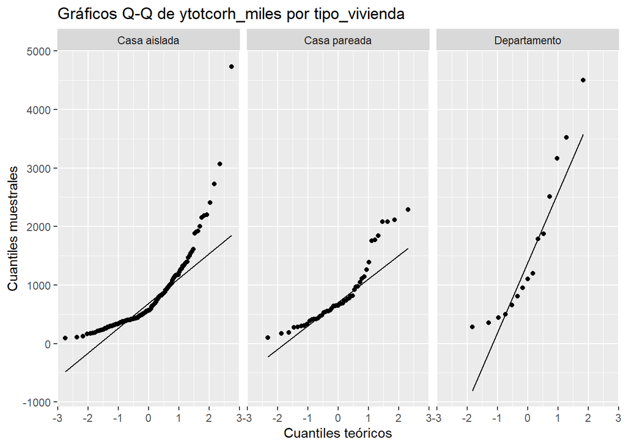

```r
# Crear variable ingreso per cápita en miles (opcional)
region_sur <- region_sur %>%
  mutate(ytotcorh_miles = ytotcorh / 1000)

# Función para hacer Q-Q plot por grupo con ggplot2
ggqqplot <- function(data, grupo_var, valor_var) {
  ggplot(data, aes(sample = .data[[valor_var]])) +
    stat_qq() +
    stat_qq_line() +
    facet_wrap(as.formula(paste("~", grupo_var))) +
    xlab("Cuantiles teóricos") +
    ylab("Cuantiles muestrales") +
    ggtitle(paste("Gráficos Q-Q de", valor_var, "por", grupo_var))
}

# Aplicar función
ggqqplot(region_sur, "tipo_vivienda", "ytotcorh_miles")
```

Como se puede observar, los datos no siguen una distrbución normal ni están balanceados (misma cantidad de datos el los grupos), por lo que se utilizará bootstrapping.

Definimos una función que calcula el estadístico de interés (estadístico F) usado por ANOVA de una vía para muestras independientes y obtenemos dicho estadístico:

```r
library(ez)
calcular_F_anova <- function(data, idx_casa_aislada, idx_casa_pareada, idx_departamento, verbose = FALSE) {
  indices <- c(idx_casa_aislada, idx_casa_pareada, idx_departamento)

  observaciones <- factor(1:length(indices))

  subset_datos <- data[indices, ]

  datos_anova <- cbind(observacion = observaciones,
                       subset_datos)

  resultado <- ezANOVA(datos_anova, dv = ytotcorh_miles, wid = observacion, between = tipo_vivienda, type = 2)

  if (verbose) {
    print(resultado)
  }

  return(resultado$ANOVA$F)
}

F.obs <- calcular_F_anova(region_sur, iCasaAislada, iCasaPareada, iDepartamento, TRUE)
```

```
## Coefficient covariances computed by hccm()
```

```
## $ANOVA
##          Effect DFn DFd        F            p p<.05        ges
## 1 tipo_vivienda   2 227 10.19453 5.757703e-05     * 0.08241698
##
## $`Levene's Test for Homogeneity of Variance`
##   DFn DFd     SSn      SSd        F            p p<.05
## 1   2 227 4704360 64375587 8.294213 0.0003337377     *
```

Después de calcular el estadístico F para comparar los ingresos entre los tipos de vivienda, tenemos que tener en cuenta que el método de bootstrap que usamos no genera automáticamente muestras que representen la hipótesis de que no hay diferencias (es decir, que todos los grupos tienen la misma media).

Por eso, para hacer que el bootstrap funcione bien y podamos comparar correctamente, primero ajustamos los datos para que cada grupo tenga la misma media y variabilidad general de la muestra. Esto nos ayuda a simular una situación donde no hay diferencias reales entre los grupos, y así poder generar una distribución del estadístico F bajo esa condición.

Con este ajuste, cuando hacemos el remuestreo, las muestras se parecen más a lo que esperaríamos si la hipótesis nula fuera cierta, y podemos evaluar si el valor F que obtuvimos es realmente significativo o no.

```r
# Calcular la media y desviación estándar global del ingreso
media_global <- mean(region_sur[["ytotcorh"]])
sd_global <- sd(region_sur[["ytotcorh"]])

# Calcular la media y desviación estándar del ingreso por tipo de vivienda
estadisticas_por_tipo <- region_sur %>%
  group_by(tipo_vivienda) %>%
  summarise(media = mean(ytotcorh), sd = sd(ytotcorh)) %>%
  as.data.frame()

# Crear una copia de los datos para ajustar bajo H0
region_sur_ajustada <- region_sur

# Ajustar los ingresos para que cada grupo tenga la misma media y desviación estándar global
region_sur_ajustada[iCasaAislada, "ytotcorh"] <- media_global +
  (region_sur_ajustada[iCasaAislada, "ytotcorh"] - estadisticas_por_tipo[1, "media"]) *
  (sd_global / estadisticas_por_tipo[1, "sd"])

region_sur_ajustada[iCasaPareada, "ytotcorh"] <- media_global +
  (region_sur_ajustada[iCasaPareada, "ytotcorh"] - estadisticas_por_tipo[2, "media"]) *
  (sd_global / estadisticas_por_tipo[2, "sd"])

region_sur_ajustada[iDepartamento, "ytotcorh"] <- media_global +
  (region_sur_ajustada[iDepartamento, "ytotcorh"] - estadisticas_por_tipo[3, "media"]) *
  (sd_global / estadisticas_por_tipo[3, "sd"])
```

```r
# Definir número de remuestreos y control de mensajes
B <- 100
verbose <- FALSE
if (B < 10) verbose <- TRUE

# Semilla para reproducibilidad
set.seed(573)

# Suponiendo que ya tienes los índices de cada grupo definidos:
iCasaAislada <- which(region_sur$tipo_vivienda == "Casa aislada")
iCasaPareada <- which(region_sur$tipo_vivienda == "Casa pareada")
iDepartamentos <- which(region_sur$tipo_vivienda == "Departamento")

# Generar las remuestras con reemplazo para cada grupo
re.iCasaAislada <- lapply(1:B, function(i) sample(iCasaAislada, replace = TRUE))
re.iCasaPareada <- lapply(1:B, function(i) sample(iCasaPareada, replace = TRUE))
re.iDepartamentos <- lapply(1:B, function(i) sample(iDepartamentos, replace = TRUE))
```

Obtenemos la distribución bootstrapping

```r
cat("Generando distribución bootstrap, por favor espera...\n")
```

```
## Generando distribución bootstrap, por favor espera...
```

```r
# Función para obtener F para la i-ésima remuestra
get_F_bootstrap <- function(i, datos_ajustados, verbose = FALSE) {
  calcular_F_anova(
    datos_ajustados,
    re.iCasaAislada[[i]],
    re.iCasaPareada[[i]],
    re.iDepartamentos[[i]],
    verbose
  )
}

# Generar la distribución bootstrap de F con manejo silencioso de mensajes
distribucion_F_bootstrap <- suppressMessages(suppressWarnings(
  sapply(1:B, function(i) get_F_bootstrap(i, region_sur_ajustada, verbose))
))
```

Se calcula el valor crítico del estadístico F al 95% usando la distribución bootstrap y el p-valor:

```r
# Calcular el valor crítico del estadístico F al 95% usando la distribución bootstrap
F_critico <- quantile(distribucion_F_bootstrap, 0.95)
cat("Valor crítico de F (95% confianza):", round(F_critico, 3), "\n")
```

```
## Valor crítico de F (95% confianza): 32.603
```

```r
# Calcular el p-valor como la proporción de remuestreos con estadístico mayor al observado
num_superior <- sum(distribucion_F_bootstrap > F.obs)
p_valor_boot <- (num_superior + 1) / (B + 1)  # corrección para evitar p=0
cat("P-valor bootstrap:", round(p_valor_boot, 3), "\n")
```

```
## P-valor bootstrap: 0.574
```

Dado a que no se rechaza la hipotesis nula, No se aplica posthoc